# 통계적학습 및 실습

기지훈 이강현

possum regression

```r
library(glmnet)
library(tidyverse)
```

#ridge lasso model

##data structures

possum(주머니쥐) 데이터 셋을 이용하여 hdlngth(머리둘레)를 예측하는 ridge lasso모델을 적합해 보겠습니다.

```r
possum<-read.csv("possum.csv")
head(possum)
```

|  | case | site | Pop | sex | age | hdlngth | skullw | totlngth | taill | footlgth | earconch | eye | chest | belly |
| --- | --- | --- | --- | --- | --- | --- | --- | --- | --- | --- | --- | --- | --- | --- |
| 1 | 1 | 1 | Vic | m | 8 | 94.1 | 60.4 | 89.0 | 36.0 | 74.5 | 54.5 | 15.2 | 28.0 | 36 |
| 2 | 2 | 1 | Vic | f | 6 | 92.5 | 57.6 | 91.5 | 36.5 | 72.5 | 51.2 | 16.0 | 28.5 | 33 |
| 3 | 3 | 1 | Vic | f | 6 | 94.0 | 60.0 | 95.5 | 39.0 | 75.4 | 51.9 | 15.5 | 30.0 | 34 |
| 4 | 4 | 1 | Vic | f | 6 | 93.2 | 57.1 | 92.0 | 38.0 | 76.1 | 52.2 | 15.2 | 28.0 | 34 |
| 5 | 5 | 1 | Vic | f | 2 | 91.5 | 56.3 | 85.5 | 36.0 | 71.0 | 53.2 | 15.1 | 28.5 | 33 |
| 6 | 6 | 1 | Vic | f | 1 | 93.1 | 54.8 | 90.5 | 35.5 | 73.2 | 53.6 | 14.2 | 30.0 | 32 |

```r
dim(possum)
```

```
## [1] 104  14
```

104개의 row와 14개의 col로 이루어진 데이터이다.

데이터의 “Pop”,“Sex” 변수가 명목형으로 지정되어있다. “Pop” 변수는 “Vic”이면 1 “other”이면 0로 코딩하였고,“sex”변수는 m이면 1 f면 0로 인코딩하였습니다.

```r
str(possum)
```

```
## 'data.frame':    104 obs. of  14 variables:
##  $ case    : int  1 2 3 4 5 6 7 8 9 10 ...
##  $ site    : int  1 1 1 1 1 1 1 1 1 1 ...
##  $ Pop     : chr  "Vic" "Vic" "Vic" "Vic" ...
##  $ sex     : chr  "m" "f" "f" "f" ...
##  $ age     : int  8 6 6 6 2 1 2 6 9 6 ...
##  $ hdlngth : num  94.1 92.5 94 93.2 91.5 93.1 95.3 94.8 93.4 91.8 ...
##  $ skullw  : num  60.4 57.6 60 57.1 56.3 54.8 58.2 57.6 56.3 58 ...
##  $ totlngth: num  89 91.5 95.5 92 85.5 90.5 89.5 91 91.5 89.5 ...
##  $ taill   : num  36 36.5 39 38 36 35.5 36 37 37 37.5 ...
##  $ footlgth: num  74.5 72.5 75.4 76.1 71 73.2 71.5 72.7 72.4 70.9 ...
##  $ earconch: num  54.5 51.2 51.9 52.2 53.2 53.6 52 53.9 52.9 53.4 ...
##  $ eye     : num  15.2 16 15.5 15.2 15.1 14.2 14.2 14.5 15.5 14.4 ...
##  $ chest   : num  28 28.5 30 28 28.5 30 30 29 28 27.5 ...
##  $ belly   : num  36 33 34 34 33 32 34.5 34 33 32 ...
```

```r
possum$Pop<-as.factor(ifelse(possum$Pop == "Vic","1","0"))
possum$sex<-as.factor(ifelse(possum$sex == "m" ,"1","0"))
```

case observation number

site 주머니쥐가 갇힌 일곱 곳 중 하나 장소 순서대로 Cambarville, Bellbird, Whian Whian, Byrangery, Conondale, Allyn River Bulburin이 있다.

Pop 현장을 “Vic Victoria”, “other”(New South Wales, Queensland)로 분류하는 요인 (“Vic”=1 , “other”=0)

sex 성별 f 여자 m 남자 (m=1,f=0)

age 나이

hdlngth 머리 둘레

skullw 두개골 폭

totlngth 총 둘레

taill 꼬리 길이

footlgth 발 길이

earconch 귀 고리 길이

eye 눈 길이

chest 가슴둘레 (in cm)

belly 배 둘레 (in cm)

## colums summary

결측값이 3개 발견하여 제거하였습니다. “hdlnght”의 분포를 확인 할 수 있습니다.

```r
attach(possum)
summary(possum)
```

```
##       case             site       Pop    sex         age
##  Min.   :  1.00   Min.   :1.000   0:58   0:43   Min.   :1.000
##  1st Qu.: 26.75   1st Qu.:1.000   1:46   1:61   1st Qu.:2.250
##  Median : 52.50   Median :3.000                 Median :3.000
##  Mean   : 52.50   Mean   :3.625                 Mean   :3.833
##  3rd Qu.: 78.25   3rd Qu.:6.000                 3rd Qu.:5.000
##  Max.   :104.00   Max.   :7.000                 Max.   :9.000
##                                                 NA's   :2
##     hdlngth           skullw         totlngth         taill
##  Min.   : 82.50   Min.   :50.00   Min.   :75.00   Min.   :32.00
##  1st Qu.: 90.67   1st Qu.:54.98   1st Qu.:84.00   1st Qu.:35.88
##  Median : 92.80   Median :56.35   Median :88.00   Median :37.00
##  Mean   : 92.60   Mean   :56.88   Mean   :87.09   Mean   :37.01
##  3rd Qu.: 94.72   3rd Qu.:58.10   3rd Qu.:90.00   3rd Qu.:38.00
##  Max.   :103.10   Max.   :68.60   Max.   :96.50   Max.   :43.00
##
##     footlgth        earconch          eye            chest          belly
##  Min.   :60.30   Min.   :40.30   Min.   :12.80   Min.   :22.0   Min.   :25.00
##  1st Qu.:64.60   1st Qu.:44.80   1st Qu.:14.40   1st Qu.:25.5   1st Qu.:31.00
##  Median :68.00   Median :46.80   Median :14.90   Median :27.0   Median :32.50
##  Mean   :68.46   Mean   :48.13   Mean   :15.05   Mean   :27.0   Mean   :32.59
##  3rd Qu.:72.50   3rd Qu.:52.00   3rd Qu.:15.72   3rd Qu.:28.0   3rd Qu.:34.12
##  Max.   :77.90   Max.   :56.20   Max.   :17.80   Max.   :32.0   Max.   :40.00
##  NA's   :1
```

```r
sum(is.na(possum))
```

```
## [1] 3
```

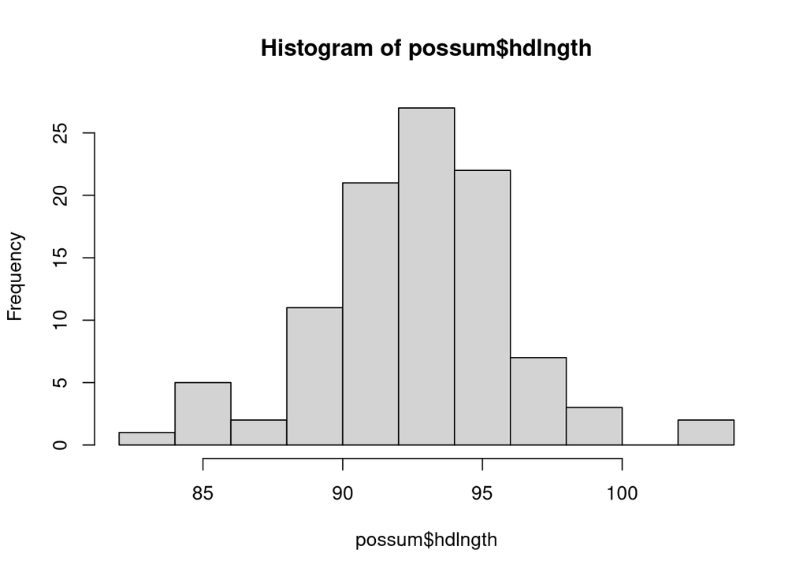

```r
possum<-na.omit(possum)
hist(possum$hdlngth)
```

선형관계로 예상가능한 변수간에 선형성을 확인하기 위하여 산점도를 그려보겠습니다.

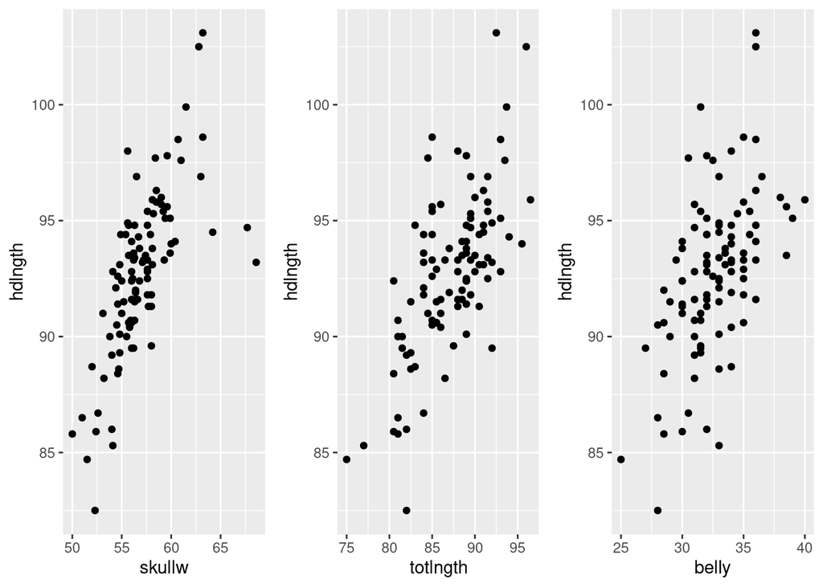

```r
g1<-ggplot(data=possum)+
  geom_point(aes(x=skullw,y=hdlngth))
g2<-ggplot(data=possum)+
  geom_point(aes(x=totlngth,y=hdlngth))
g3<-ggplot(data=possum)+
  geom_point(aes(x=belly,y=hdlngth))


gridExtra::grid.arrange(g1,g2,g3,ncol=3)
```

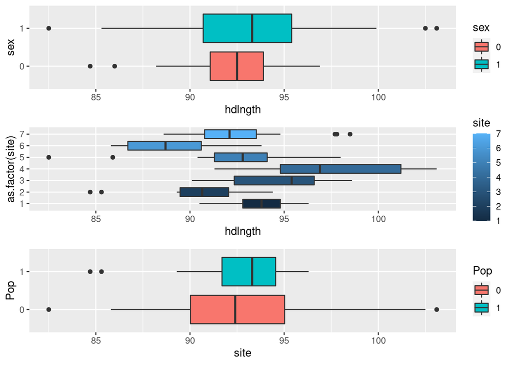

```r
a1<-ggplot(data=possum,mapping=aes(x=sex,y=hdlngth,fill=sex))+
  geom_boxplot()+coord_flip()
a2<-ggplot(data=possum,mapping=aes(x=as.factor(site),y=hdlngth,fill=site))+
  geom_boxplot()+coord_flip()
a3<-ggplot(data=possum,mapping=aes(x=Pop,y=hdlngth,fill=Pop))+
  geom_boxplot()+coord_flip()+labs(y="site")

gridExtra::grid.arrange(a1,a2,a3)
```

male의 hdlngth가 female의 hlngth의 길이보다 전반적으로 넓은범위를 가지고 평균적으로 male이 더 큰값을 가지는것을 확인 할 수있다. 서식지가 other의 hdlngth가 Vic의 hlngth의 길이보다 전반적으로 넓은범위를 가지고 평균적으로 Pop서식지가 더 큰값을 가지는것을 확인 할 수있다. site,levels=c(“Cambarville”, “Bellbird”, “Whian Whian”, “Byrangery”, “Conondale”, “Allyn River”, “Bulburin”) 순으로 정렬해 있다. Byrangery에 위치한 possum이 더 큰 hdlngth값을 가진는 것을 확인 할 수 있다. “Allyn River”에 위치한 possum이 전반적으로 작은 hdlngth를 가지는 것을 확인 할 수 있다.

반응변수 y 를 ’hdlngth’로 하여 모델링 해 보겠습니다. 먼저 train set과 test셋을 7:3으로 split하였습니다. “Pop” 변수는 “Vic”이면 1 “other”이면 0로 코딩하였고,“sex”변수는 m이면 1 f면 0로 코딩하였습니다. “case”,intercept colum은 제거해주었습니다.

```r
set.seed(123)
ind<-sample(dim(possum)[1], size=dim(possum)[1]*0.7, replace = FALSE)
possum.train<-possum[ind,]
possum.test<-possum[-ind,]
x.train<-model.matrix(hdlngth~.,data=possum.train)[,-c(1,2)]
y.train<-possum.train$hdlngth
x.test<-model.matrix(hdlngth~.,data=possum.test)[,-c(1,2)]
y.test<-possum.test$hdlngth
```

후보 $\lambda$ 값으로 $10$부터 $-10$까지 동일한 간격으로 이루어진 수열을 `exp(1)`의 거듭제곱으로 한 값을 고려하여 gird search를 하였습니다.

##ridge model

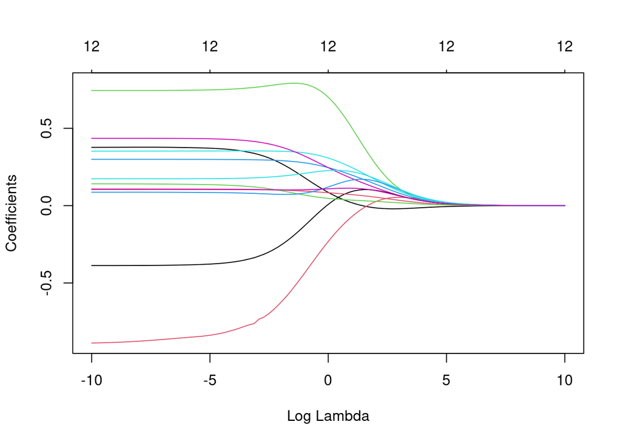

```r
grid = exp(1)^(seq(10,-10, length = 100))
ridge<-glmnet(x.train,y.train,alpha=0,lambda=grid,family = 'gaussian')
plot(ridge,xvar='lambda')
```

교차검증을 통해 최적의 $\lambda$를 선택하겠습니다. 데이터의 크기가 크지않으므로 fold=5로 하여 교차검증을 실시하였습니다. 교차검증오차가 최소가 되게 하는 best lambda값을 0.8548508로 지정하겠습니다.

```r
set.seed(123)
  cv.ridge <- cv.glmnet(x.train,y.train,nfold=5,alpha=0)
bestlam <- cv.ridge$lambda.min
bestlam
```

```
## [1] 0.8548508
```

이제 bestlam를 이용하여 만든 ridge모델에 test데이터를 적학하여 MSE를 구해보겠습니다.

```r
ridge.pred<-predict(ridge,x.test,s = bestlam)
ridge.mse<-mean((ridge.pred-y.test)^2)
ridge.mse
```

```
## [1] 6.138413
```

##lasso model 이번엔 lasso medel을 적용하겠습니다. 데이터는 앞에서 사용한 데이터를 사용하겠습니다. grid search를 하기위한 lambda또한 같은 범위를 사용하였습니다.

```r
lasso<-glmnet(x.train,y.train,alpha=1,family = 'gaussian',lambda=grid)
```

ridge에서와 같이 nfold를 5로하여 교차검증오류가 최소가 되는 lambda를 찾아주겠습니다. bestlam2=0.1795733 로 정하였습니다.

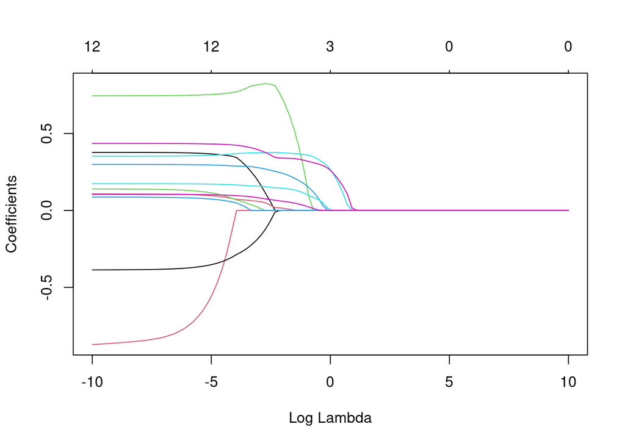

```r
set.seed(123)
cv.lasso<-cv.glmnet(x.train,y.train,nfold=5,lambda = grid)
bestlam2<-cv.lasso$lambda.min
plot(lasso,xvar='lambda')
```

```r
bestlam2
```

```
## [1] 0.1795733
```

여기서 lasso 모델은 변수선택기능이 있어서 ${beta}$를 0으로 하여 모델을 축소시킵니다.

```r
predict(lasso,s=bestlam2,type="coefficients")
```

```
## 13 x 1 sparse Matrix of class "dgCMatrix"
##                       s1
## (Intercept) 34.727128244
## site         .
## Pop1         .
## sex1         0.617858682
## age          0.224951741
## skullw       0.371779858
## totlngth     0.338523330
## taill        .
## footlgth     0.007685197
## earconch     .
## eye          .
## chest        0.138953336
## belly        0.053658599
```

변수선택결과 “site”,“Pop”,“taill”,“earconch”,“eye”변수가 제거되었습니다. 이렇게 선택된 변수로 만들어진 lasso 모델을 test데이터에 적합시켜보겠습니다.

```r
lasso.pred<-predict(lasso,x.test,s=bestlam2)
lasso.mse<-mean((lasso.pred-y.test)^2)
lasso.mse
```

```
## [1] 6.642636
```

##regsubset

이번엔 lasso에서 선택된 변수와 부분선택법에서 선택된 변수간 차이를 확인해보겠습니다.최상의 부분선택법은 rss값을 기준으로 합니다. 일딴 14개의 변수를 모두 포함하는 선형모델을 만들어 보겠습니다.

```r
library(leaps)
regfit.full <- regsubsets(hdlngth ~ ., possum,nvmax=14)
reg.summary<-summary(regfit.full)
```

```r
names(reg.summary)
```

```
## [1] "which"  "rsq"    "rss"    "adjr2"  "cp"     "bic"    "outmat" "obj"
```

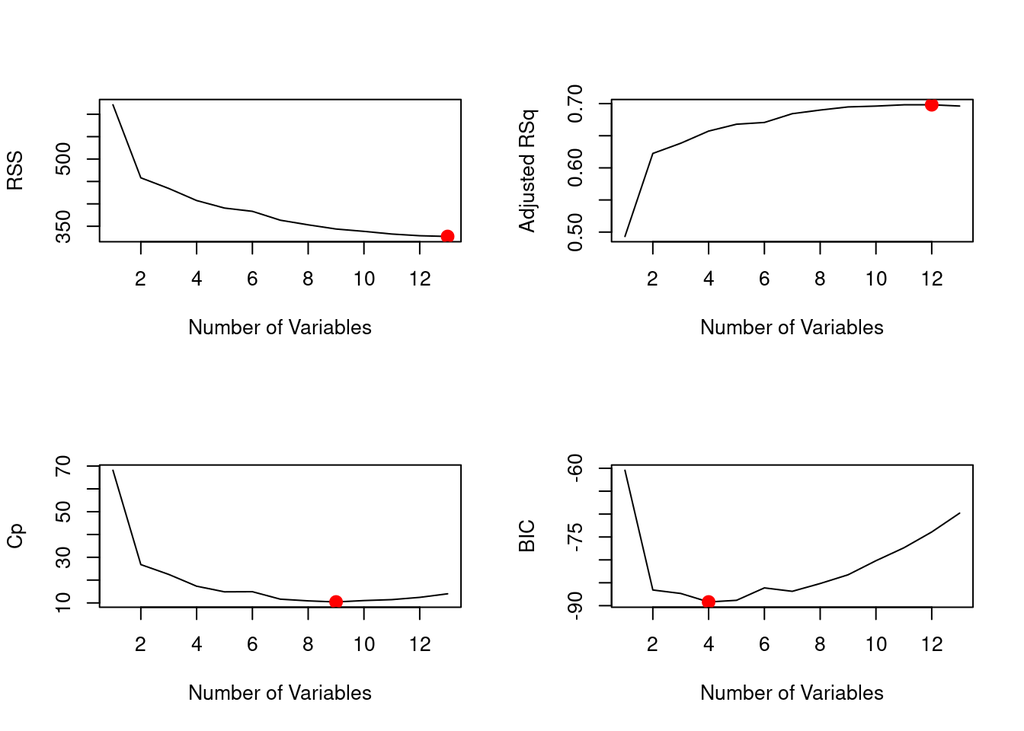

```r
par(mfrow = c(2, 2))
plot(reg.summary$rss, xlab = "Number of Variables",
    ylab = "RSS", type = "l")
rss.min<-which.min(reg.summary$rss)
points(rss.min,reg.summary$rss[rss.min],col="red",cex=2,pch=20)

plot(reg.summary$adjr2, xlab = "Number of Variables",
    ylab = "Adjusted RSq", type = "l")
adjr2.max<-which.max(reg.summary$adjr2)
points(adjr2.max, reg.summary$adjr2[adjr2.max], col = "red", cex = 2,
    pch = 20)

plot(reg.summary$cp, xlab = "Number of Variables",
    ylab = "Cp", type = "l")
cp.min<-which.min(reg.summary$cp)
points(cp.min, reg.summary$cp[cp.min], col = "red", cex = 2,
    pch = 20)

plot(reg.summary$bic, xlab = "Number of Variables",
    ylab = "BIC", type = "l")
bic.min<-which.min(reg.summary$bic)
points(bic.min, reg.summary$bic[bic.min], col = "red", cex = 2,
    pch = 20)
```

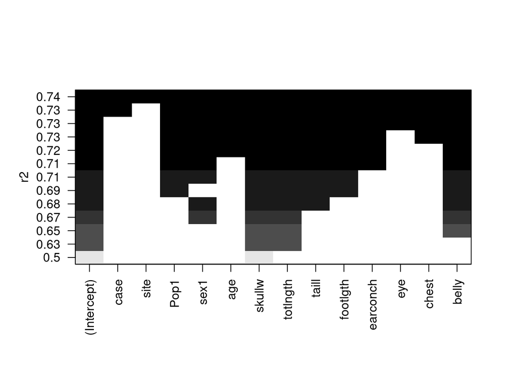

```r
plot(regfit.full, scale = "r2")
```

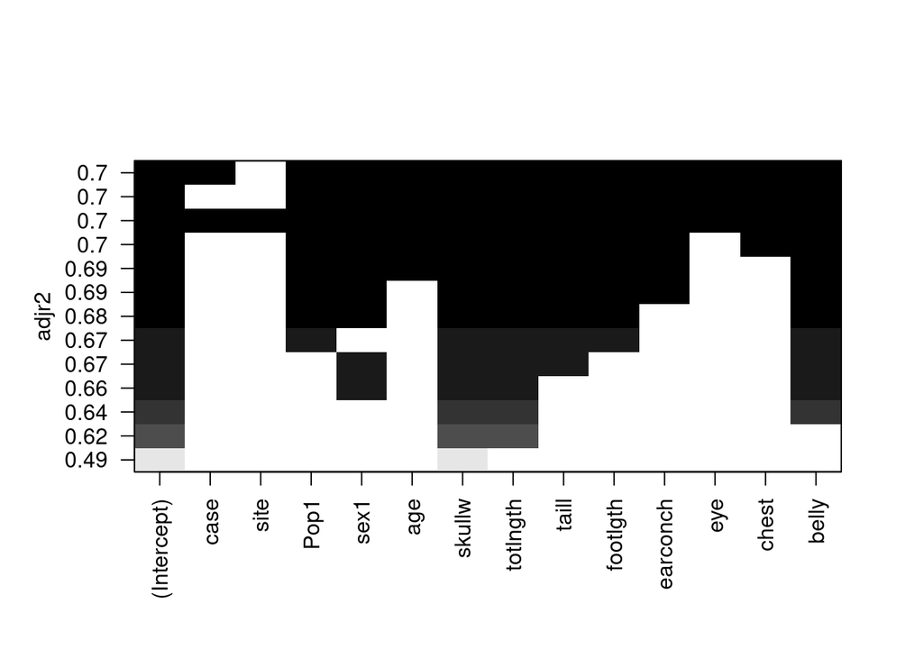

```r
plot(regfit.full, scale = "adjr2")
```

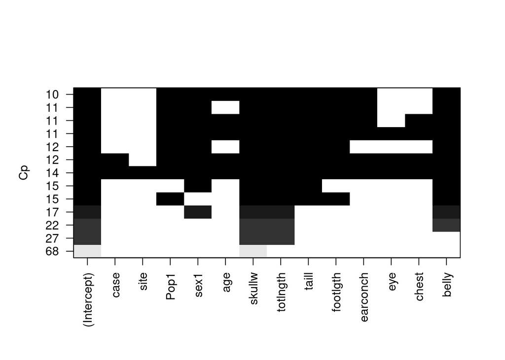

```r
plot(regfit.full, scale = "Cp")
```

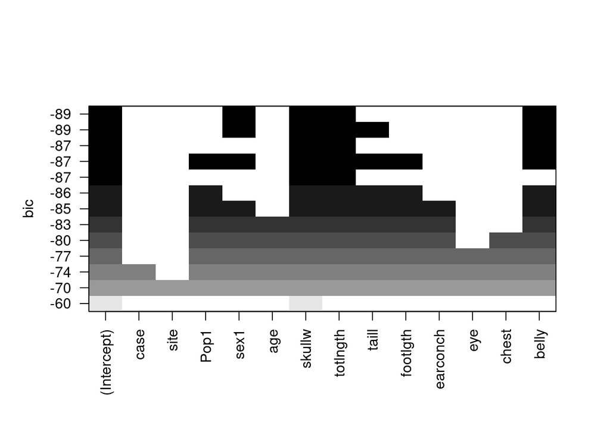

```r
plot(regfit.full, scale = "bic")
```

여기서 가장 간단한 모델인 bic값이 가장 최소가 되는 변수의 개수 4로 하여 만들어진 모델의 coefficient를 확인해보겠습니다.

```r
coef(regfit.full,4)
```

```
## (Intercept)        sex1      skullw    totlngth       belly
##  29.0736276   1.0890151   0.4642122   0.3325859   0.2314638
```

이렇게 선택된 선형 모델을 만들어 설명변수와 “hdlngth”간의 관계를 확인할 수 있습니다. 그리고 이 때의 mse 값을 구해보겠습니다.

```r
form<-as.formula('hdlngth~sex+skullw+totlngth+belly')
reg.fit<-lm(form,data=possum,subset = ind)
summary(reg.fit)
```

```
##
## Call:
## lm(formula = form, data = possum, subset = ind)
##
## Residuals:
##     Min      1Q  Median      3Q     Max
## -5.7277 -1.0018 -0.0598  1.0526  5.4320
##
## Coefficients:
##             Estimate Std. Error t value Pr(>|t|)
## (Intercept) 28.11168    5.07153   5.543 5.81e-07 ***
## sex1         1.02476    0.45713   2.242   0.0284 *
## skullw       0.42923    0.09807   4.377 4.47e-05 ***
## totlngth     0.38364    0.06950   5.520 6.34e-07 ***
## belly        0.18514    0.09295   1.992   0.0506 .
## ---
## Signif. codes:  0 '***' 0.001 '**' 0.01 '*' 0.05 '.' 0.1 ' ' 1
##
## Residual standard error: 1.856 on 65 degrees of freedom
## Multiple R-squared:  0.7193, Adjusted R-squared:  0.702
## F-statistic: 41.63 on 4 and 65 DF,  p-value: < 2.2e-16
```

```r
reg.pred<-predict(reg.fit,possum.test)
reg.mse<-mean((reg.pred-y.test)^2)
reg.mse
```

```
## [1] 6.052873
```

lasso에서 선택된 변수와 subset방법에서 선택된 변수의 차이를 확인해 보겠습니다.

```r
predict(lasso,s=bestlam2,type="coefficients")
```

```
## 13 x 1 sparse Matrix of class "dgCMatrix"
##                       s1
## (Intercept) 34.727128244
## site         .
## Pop1         .
## sex1         0.617858682
## age          0.224951741
## skullw       0.371779858
## totlngth     0.338523330
## taill        .
## footlgth     0.007685197
## earconch     .
## eye          .
## chest        0.138953336
## belly        0.053658599
```

```r
coef(reg.fit)
```

```
## (Intercept)        sex1      skullw    totlngth       belly
##  28.1116772   1.0247640   0.4292349   0.3836385   0.1851404
```

lasso에서는 “sex”,“age”,“skullw”,“totlngth”,“footlgth”,“chest”,“belly” regsubset에서는 “sex”“skullw”,“totlngth”,“belly” 변수가 선택되었디.

lasso에서 선택된 “age”,“footlgth”,“chest”변수가 제거된것을 확인할 수 있습니다.

##결과

```r
c(lasso.mse,ridge.mse,reg.mse)
```

```
## [1] 6.642636 6.138413 6.052873
```

세가지 선형모형에서 mse의 값을 비교하였을 때 regsubset으로 변수를 선택하여 만든 모델의 mse값이 가장 작게 나타났습니다. 부분선택법으로 모델링하여 선택된 설명변수인 skullw,totlngth,belly변수는 처음 EDA과정에서 예상한것과 같이 hdlnght변수와 양의상관관계를 가지는 것을 확인할 수 있었습니다.